# Volume 4: Introduction to Initial Value Problems and Boundary Value Problems

```python
import numpy as np
from scipy.integrate import solve_ivp
from scipy.integrate import solve_bvp
import matplotlib.pyplot as plt
from mpl_toolkits import mplot3d
```

### Problem 1

Use solve_ivp to solve for $y$ in the equation $y'' - y = sin(t)$ with initial conditions $y(0)= -\frac{1}{2}$, $y'(0) = 0$ and plot your solution on the interval $[0,5]$. Compare this to the analytic solution $y=-\frac{1}{2}(e^{-t}+sin(t))$.

Note: Using max_step = 0.1 with give you a smoother graph here

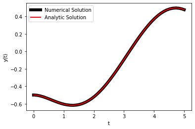

```python
#set up ode system
def ode(t, y):
    '''defines ode system'''
    return np.array([y[1], np.sin(t) + y[0]])

#span and intial conditions
t_span = (0, 5)
time = np.linspace(t_span[0], t_span[-1], 1000)
y0 = np.array([-0.5, 0])

#solve and defined analytic solution
sol = solve_ivp(ode, t_span, y0, max_step=0.1)
analytic = lambda t: -0.5*(np.exp(-t) + np.sin(t))

#plot and show everything
plt.plot(sol.t, sol.y[0], color='k', linewidth=6, label='Numerical Solution')
plt.plot(time, analytic(time), color='r', linewidth=2, label='Analytic Solution')
plt.xlabel('t')
plt.ylabel('y(t)')
plt.legend(loc='best')
plt.show()
```

### Problem 2

Use solve_bvp to solve for $y$ in the equation $y'+y''=-\frac{1}{4}e^{-0.5t}+sin(t)-cos(t)$ with boundary conditions $y(0)=6$ and $y'(5)=-0.324705$ and plot your solution on the interval $[0,5]$. Use an initial guess of all ones. Compare this to the analytic solution $y =e^{-0.5t}-sin(t)+5$.

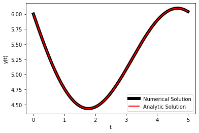

```python
#set up ode system and boundary conditions
def ode_bvp(t, y):
    '''defines ode system'''
    return np.array([y[1], -y[1] - 0.25*np.exp(-0.5*t) + np.sin(t) - np.cos(t)])
def bc(ya, yb):
    '''defines boundary conditions'''
    return np.array([ya[0] - 6, yb[1] + 0.324705])

#set up t values and initial conditions
t_steps = 200
t = np.linspace(0, 5, t_steps)
y0 = np.ones((2, t_steps))

#solve and set analytic function
sol = solve_bvp(ode_bvp, bc, t, y0)
analytic_bvp = lambda t: np.exp(-0.5*t) - np.sin(t) + 5

#plot and show
plt.plot(sol.x, sol.y[0], color='k', linewidth=6, label='Numerical Solution')
plt.plot(t, analytic_bvp(t), color='r', linewidth=2, label='Analytic Solution')
plt.xlabel('t')
plt.ylabel('y(t)')
plt.legend(loc='best')
plt.show()
```

### Problem 3

Use solve_bvp to solve for $y$ in the equation $y''=(1-y')*10y$ with boundary conditions $y(0)=-1$ and $y(1)=\frac{3}{2}$ and plot your solution on the interval $[0,1]$. Use an initial guess of 10. Compare this to the the same solution using an initial guess of 9.99.

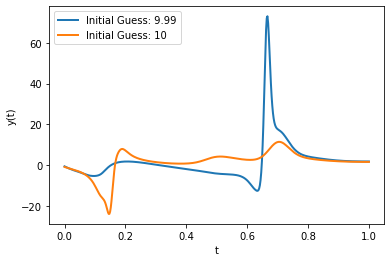

```python
#set up ode and boundary conditions
def ode_3(t, y):
    '''defines ode system'''
    return np.array([y[1], (1 - y[1])*10*y[0]])
def bc_3(ya, yb):
    '''defines boundary conditions'''
    return np.array([ya[0] +1, yb[0] - 1.5])

#set up time stemps and the two initial conditions
t_steps = 50
t = np.linspace(0, 1, t_steps)
y0_9 = 9.99 * np.ones((2, t_steps))
y0_10 = 10 * np.ones((2, t_steps))

#get two solutions
sol1 = solve_bvp(ode_3, bc_3, t, y0_9)
sol2 = solve_bvp(ode_3, bc_3, t, y0_10)

#plot and show
plt.plot(sol1.x, sol1.y[0], linewidth=2, label='Initial Guess: 9.99')
plt.plot(sol2.x, sol2.y[0], linewidth=2, label='Initial Guess: 10')
plt.xlabel('t')
plt.ylabel('y(t)')
plt.legend(loc='best')
plt.show()
```

### Problem 4

Use solve_ivp to solve the Four-Wing Attractor as described in equations (1.2), (1.3), and (1.4) where $a=0.2$, $b = 0.01$, and $c = -0.4$. Try this with 3 different initial values and plot (in three dimensions) the 3 corresponding graphs.

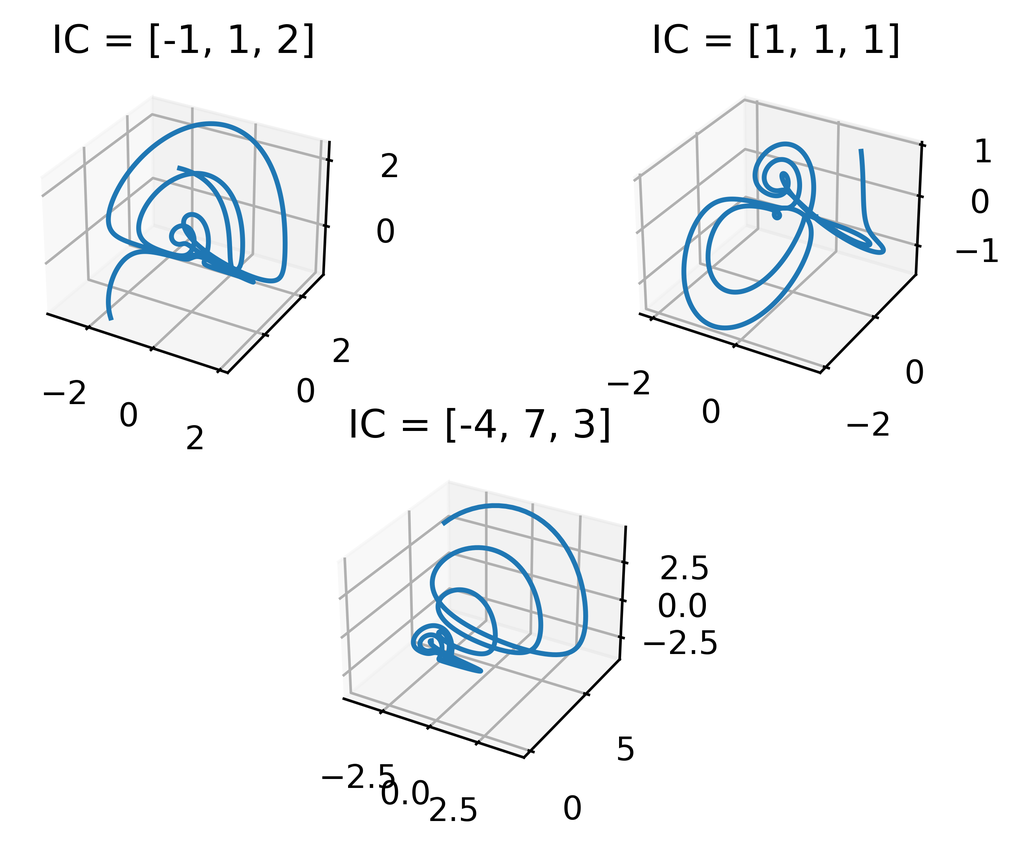

```python
#set ode system
def ode_4(t, y):
    '''defines ode system'''
    a = 0.2
    b = 0.01
    c = -0.4
    return np.array([a*y[0] + y[1]*y[2], b*y[0] + c*y[1] - y[0]*y[2], -y[2] - y[0]*y[1]])

#set time span and initial conditions
t_span = (0, 100)
y1 = np.array([1, 1, 1])
y2 = np.array([-1, 1, 2])
y3 = np.array([-4, 7, 3])

#get 3 solutions
sol1 = solve_ivp(ode_4, t_span, y1, max_step=0.01)
sol2 = solve_ivp(ode_4, t_span, y2, max_step=0.01)
sol3 = solve_ivp(ode_4, t_span, y3, max_step=0.01)


#plot on a 3d figure and show figures
fig = plt.figure()
fig.set_dpi(600)
ax = fig.add_subplot(222, projection='3d')
ax.plot(sol1.y[0], sol1.y[1],sol1.y[2])
ax.set_title('IC = [1, 1, 1]')

ax = fig.add_subplot(221, projection='3d')
ax.plot(sol2.y[0], sol2.y[1],sol2.y[2])
ax.set_title('IC = [-1, 1, 2]')

ax = fig.add_subplot(212, projection='3d')
ax.plot(sol3.y[0], sol3.y[1],sol3.y[2])
ax.set_title('IC = [-4, 7, 3]')


plt.show()
```